# Default GMSE data structures

GMSE: an R package for generalised management strategy evaluation (Supporting Information 7)

A. Bradley Duthie¹³, Jeremy J. Cusack¹, Isabel L. Jones¹, Jeroen Minderman¹, Erlend B. Nilsen², Rocío A. Pozo¹, O. Sarobidy Rakotonarivo¹, Bram Van Moorter², and Nils Bunnefeld¹

[1] Biological and Environmental Sciences, University of Stirling, Stirling, UK [2] Norwegian Institute for Nature Research, Trondheim, Norway [3] alexander.duthie@stir.ac.uk

# The most important (default) GMSE data structures

The default sub-models of GMSE (`resource`, `observation`, `manager`, and `user`) use a small number of default data structures to hold the information needed in simulations. While these default sub-models do not necessarily need to be used in every run in GMSE (see use of `gmse_apply`), they will be used in any run of the `gmse` function, and in any call of the `gmse_apply` function that does not run with entirely custom sub-models. Simulation and model inference do not require an understanding of the default data structures, but such an understanding can be especially useful when running `gmse_apply` if there is a need to extract uncommonly used information, change key simulated values (e.g., landscape properties, agent budgets, or resource movement rules, as in SI4), or build custom individual-based sub-models. Here we provide a brief explanation of the following key data structures (each name below is listed as it is named in the output `gmse_apply` when `get_res = "Full"`).

1. `AGENTS`
2. `resource_array` (or `RESOURCES`)
3. `observation_array` (or `OBSERVATION`)
4. `manager_array` (or `COST`)
5. `user_array` (or `ACTION`)
6. `LAND`

Note that these are not the only data structures used in GMSE, but they are the only ones that can be easily modified in GMSE v0.4.0.7 (see, e.g., SI4), so they are the ones that we focus on here. Additionally, any custom subfunction that returns an array rather than a single value should adhere to the same structure as these defaults if any default GMSE functions are to be used in `gmse_apply`. We can investigate each data structure by running a single simulation of `gmse_apply`.

```r
sim <- gmse_apply(get_res = "Full");
```

The full list output of `sim` holds each structure by name (in the case where two names are used, e.g., `resource_array` and `RESOURCES`, both are identical, but the lower case `resource_array` takes precedence in case of a change). Each data structure can be examined, changed, and incorporated into a new simulation (e.g., `new_sim <- gmse_apply(old_list = sim)`).

# 1. AGENTS

The `AGENTS` data structure is a two dimensional array with a fixed number of 27 columns and a number of rows that is always equal to the sum of the number of manager and users (i.e., each row is an individual agent).

```r
print(sim$AGENTS);
```

[output not shown]

[output cut: 17 more lines]

In the default case above, there are five agents (one manager and four users), each represented by a unique row. Columns in the array represent the agent traits listed below.

1. ID (each agent gets a unique number)
2. Type 1 (0 indicates the manager; 1 indicates users)
3. Type 2 (currently unused)
4. Type 3 (currently unused)
5. x-location on the landscape (typically ignored)
6. y-location on the landscape (typically ignored)
7. Movement distance (typically ignored)
8. Time parameter (typically ignored)
9. Distance of vision (currently used only for managers)
10. Error parameter (currently unused)
11. Resource marking parameter (currently used only for managers)
12. Resource tally parameter (currently used only for managers)
13. How many resources an agent has in view (unused)
14. Total number of cells owned by an agent
15. Unused column
16. Yield from owned land (zero for users when default `land_ownership = FALSE`)
17. Agent’s baseline budget
18. Agent’s perception of the efficacy of scaring one resource
19. Agent’s perception of the efficacy of culling one resource
20. Agent’s perception of the efficacy of castrating one resource
21. Agent’s perception of the efficacy of feeding one resource
22. Agent’s perception of the efficacy of helping offspring of one resource
23. Agent’s perception of the efficacy of tending the crop on one landscape cell
24. Agent’s perception of the efficacy of killing the crop on one landscape cell
25. Increment added to the manager’s (row 1) baseline budget caused by a budget bonus
26. Increment added to an agent’s budget caused by yield
27. Unused column

Note that for the perceptions of the efficacy of different actions (columns 18-24), this relates to whatever it is that the agents are acting upon. For example, for columns 18-22, actions are on the resources, so if an agent’s perception of the efficacy of scaring is -1, this means that they believe that scaring a resource will decrease the number of resources affecting them by 1 (lower default values for landowners are caused based on the probability of a scared resource landing on a different cell owned by the same agent). For columns 23-24, actions are on the landscape, so if an agent tends the crop on one landscape cell, this value defines an agent’s perception of how much yield on that cell will increase.

It is obvious from the above list that several columns represent traits that are either typically ignored or currently not in use. This is intended to allow for easier future development of default model options and potential customisation of sub-models in `gmse_apply`. We anticipate that future versions of GMSE will contain multiple user types with unique traits and among-user interactions.

# 2. resource_array

The `resource_array` (also accessible as `RESOURCES`) is a two dimensional array with a fixed number of 22 columns and a number of rows that is always equal to the total number of resources (each row is an individual resource). In the above simulation, `sim$resource_array` includes 1091 rows, so we only print out the first eight for illustration.

```r
print(sim$resource_array[1:8,]);
```

[output not shown]

# 3. observation_array

The `observation_array` (also accessible as `OBSERVATION`) is a two dimensional array, the number of rows and columns of which depend on the type of observation being made (i.e., `observe_type`, which can take integer values from 0-3; see the [GMSE reference manual](https://cran.r-project.org/package=GMSE) for more information about built-in observation types that are available in GMSE). The first 20 columns of `observation_array` contain the same individual resource traits as in `resource_array`, while any additional columns provide information about how and when a resource was observed. The number of rows in `observation_array` is always equal to or less than that of `resource_array`; each resource that is observed at least once is placed into one unique row, while unobserved resources are not included as rows in the `observation_array`. In `sim`, there are 49 rows, meaning that 1042 resources were not observed at all in this time step. Below, we print out the first eight rows of the observation array.

```r
print(sim$observation_array[1:8,]);
```

[output not shown]

[output cut: 73 more lines]

# 4. manager_array

For context, it might be easier to understand `manager_array` after reading about `user_array` below. The `manager_array` (also accessible as `COST`) is a three dimensional array, each layer of which corresponds to a unique agent (rows in `AGENT` correpond to layers in `manager_array`). Hence, in the simulation output `sim$manager_array`, there are 5 layers. Each layer in `manager_array` has 13 columns, and a number of rows that varies depending on the number of agents and resource types. As of GMSE v0.4.0.7, only the first three rows are used. Two layers of `sim$manager_array` are shown below, the first being that of the manager and the second being that of the first user.

```r
print(sim$manager_array[,,1:2]);
```

```
## , , 1
##
##        [,1]   [,2]   [,3]   [,4]   [,5]   [,6]   [,7]   [,8]   [,9]  [,10]
## [1,] 100001 100001 100001 100001 100001 100001 100001 100001 100001 100001
## [2,] 100001 100001 100001 100001 100001 100001 100001 100001 100001 100001
## [3,] 100001 100001 100001 100001 100001 100001 100001 100001     10 100001
## [4,] 100001 100001 100001 100001 100001 100001 100001 100001 100001 100001
## [5,] 100001 100001 100001 100001 100001 100001 100001 100001 100001 100001
## [6,] 100001 100001 100001 100001 100001 100001 100001 100001 100001 100001
## [7,] 100001 100001 100001 100001 100001 100001 100001 100001 100001 100001
##       [,11]  [,12]  [,13]
## [1,] 100001 100001     10
## [2,] 100001 100001     10
## [3,] 100001 100001     10
## [4,] 100001 100001 100001
```

[output cut: 22 more lines]

Each element in the array indicates the cost of performing a particular action. In the code, this is the cost of changing an element in `user_array` (which has the same dimensions as `manager_array`). The minimum value in `sim$manager_array` is therefore 10, reflecting the default `minimum_cost` value of 10. The maximum value is 100001, which is one higher than the maximum allowed manager or user budget. Where a cost is 100001, actions can therefore never be performed. An explanation of the rows and columns of `manager_array` is provided below in the description of `user_array`.

# 5. user_array

The `user_array` (also accessible as `ACTION`) is a three dimensional array, each layer of which corresponds to a unique agent. When considering the three dimensional `user_array`, it is helpful to keep in mind that each layer corresponds to the actions of a particular agent, that each column corresponds to a particular type of action, and that each row corresponds to a particular resource, agent, or group that the action will affect. The cost of performing any action in this array is held in `manager_array`, wherein an action’s cost in `manager_array` is held in the same array element as the action itself in `user_array`. Recall from the manager array that the first layer of `user_array` corresponds to the manager actions, and that remaining layers correspond to user actions; there are therefore as many layers in `user_array` as there are agents in the model, and each row of `AGENTS` corresponds to equivalent layer of `user_array` (e.g., the manager agent, ID = 1, is in the first row of `AGENTS` and the first layer of `user_array`). The first two layers of `user_array` are shown below.

```r
print(sim$user_array[,,1:2]);
```

[output not shown]

Note that there are more columns in this array than there are possible actions in GMSE. This is because there are several columns that do not map to actions per se, but properties of agents. As of GMSE v0.4.0.7, these properties cannot be changed by other agents. Column of `user_array` are as follows.

1. The type of agent or resource being affected by an action. A value of -2 indicates that actions have a direct effect on a resource (e.g., scaring, culling, etc.). A value of -1 indicates that actions have a direct effect on a landscape layer. Positive integer values indicate actions that affect other agents, where each integer corresponds to the agents’ IDs. Where the integer value is identical with the agent’s own ID (e.g., row 3 in layer 1 where the element `sim$user_array[3, 1, 1] = 1`), actions affect all other agents in the model. As of GMSE v0.4.0.7, all rows except 1-3 are unused because agents do not affect one anothers actions individually; they either affect all other agents’ actions indiscriminately (in the case of the manager setting policy) or do not (directly) affect other agents’ actions at all (in the case of users). This data structure, however, is designed so that future versions of GMSE will allow users to affect one another directly (representing, e.g., different groups of agents lobbying for different interests, among-user conflict, etc.).
2. Type 1 of the agent or resource of interest (in practice, this is currently unused).
3. Type 2 of the agent or resource of interest (currently unused).
4. Type 3 of the agent or resource of interest (currently unused).

5. Utility associated with the recipient of the action. For example, in the case of the resource (row 1), positive values indicate that the agent wants more of these resources, while negative values indicate that the agent wants fewer. In the case of the manager (layer 1), the value in the first row equals `manage_target`, while the value in the third row is the change in resource number needed to achieve the target value (i.e., `manage_target =` 1000, and the manager’s estimate is `sim$observation_vector =` 1111.1111111. The former minus the latter is -111.11111).

In the genetic algorithm, values in elements of a `user_array` layer are potentially modified according to each agent’s objective, as constrained by costs in `manager_array`.

# 6. LAND

```r
print(sim$LAND[1:8,1:8,]);
```

[output not shown]

In the case of the above, all of the cells in this square patch of landscape are owned by agent 1 (i.e., the manager; see `sim$LAND[,,3]`). This occurs if `land_ownership = FALSE` and users are prohibited from owning land. We can also see that crop production on this patch of land has been decreased from its initialised value of 1 in several cells as a consequence of consumption by resources (see `sim$LAND[„2]`). By default, landscape yield starts each time step at a value of 1, and hence replenishes in each time even if consumed in the previous time step. Users that own landscape cells (when `land_ownership = TRUE`) can increase yield above 1 using the `tend_crop_yld` action. If resources consume landscape yield, the value of yield can drop to a minimum value of zero.

### 6.1. Default land distribution algorithm

In SI4, we show how landscape cell values can be manipulated to customise the placement of land ownership. By default, GMSE v0.6.0.0+ places the ownership of landscape cells using a shortest-splitline algorithm (see the lab notebook for [a detailed explanation](https://confoobio.github.io/gmse/notebook/gmse_notes.html#u-10-MAY-2020)). The algorithm splits the landscape evenly into smaller and smaller rectangles until a sufficient number of rectangles are produced for all users to own a similar amount of land (note that how uniformly land is partitioned among users will naturally be influenced by how evenly the total number of landscape cells can be divided among them). Below is an example in which land of `land_dim_1 = 64` and `land_dim_2 = 64` is partitioned equally among eight users.

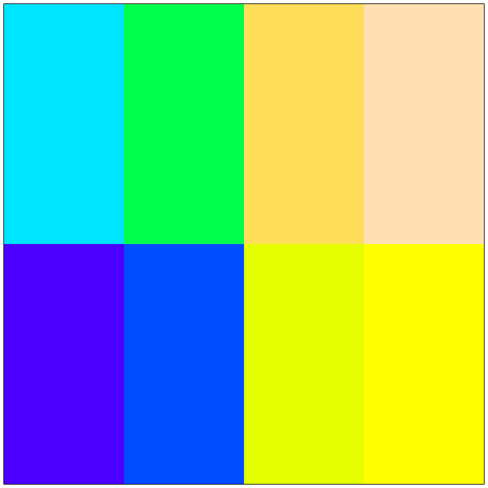

Note that all users own exactly 512 cells on the landscape. A bit more complexity can be generated by an uneven landscape of `land_dim_1 = 80` and `land_dim_2 = 100`, with land allocated among nine users.

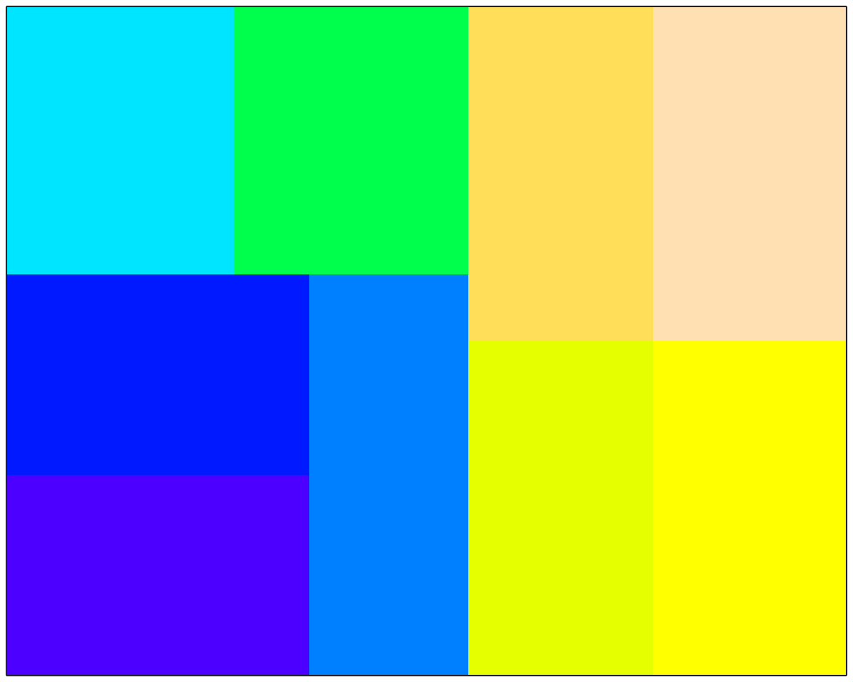

In the case of the above landscape, the number of cells allocated to each user ranges from 864 to 920.

### 6.2. Varying land ownership: `ownership_var`

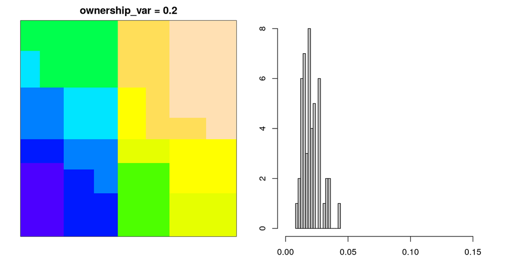

As can be seen from the frequency distribution, in this case, all users own between 1% and 4.3% of the landscape.

By contrast, when increasing `ownership_var` to 0.8, overall inequity increases substantially:

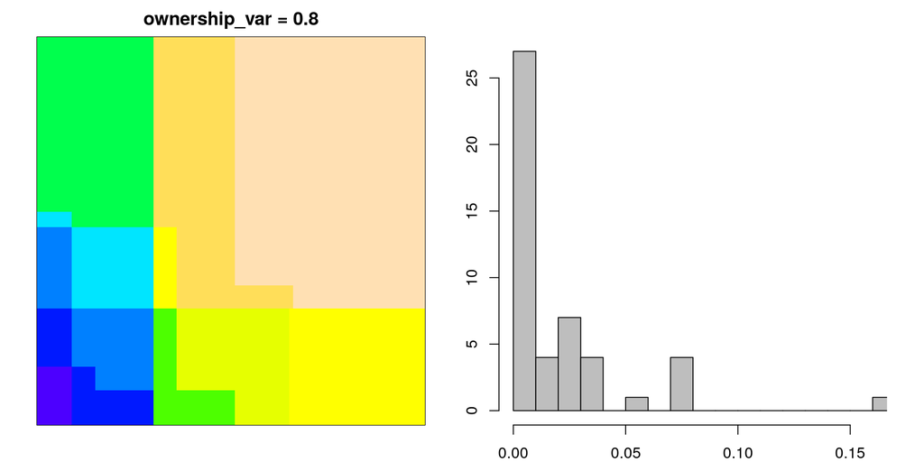

In the latter case, user ownership varies between <0.001% and 16.7%.

It should be noted that it is still entirely possible for the user to customise landscapes to whatever extent necessary, using custom `gmse_apply` loops as described previously; however, the new `ownership_var` provides an option in GMSE to alter landscape ownership in a relatively straightforward way.

### 6.3. Public land

Public land is placed on the landscape whenever `public_land > 0`, with `public_land` defining the proportion of landscape cells that are not be owned by an user. When the expected number of cells to be allocated to public land is calculated to be equal to or greater than that allocated to a single user, public land is allocated in a block as is with users. For example, the below shows a landscape in which `public_land = 0.5`, with seven other users owning land.

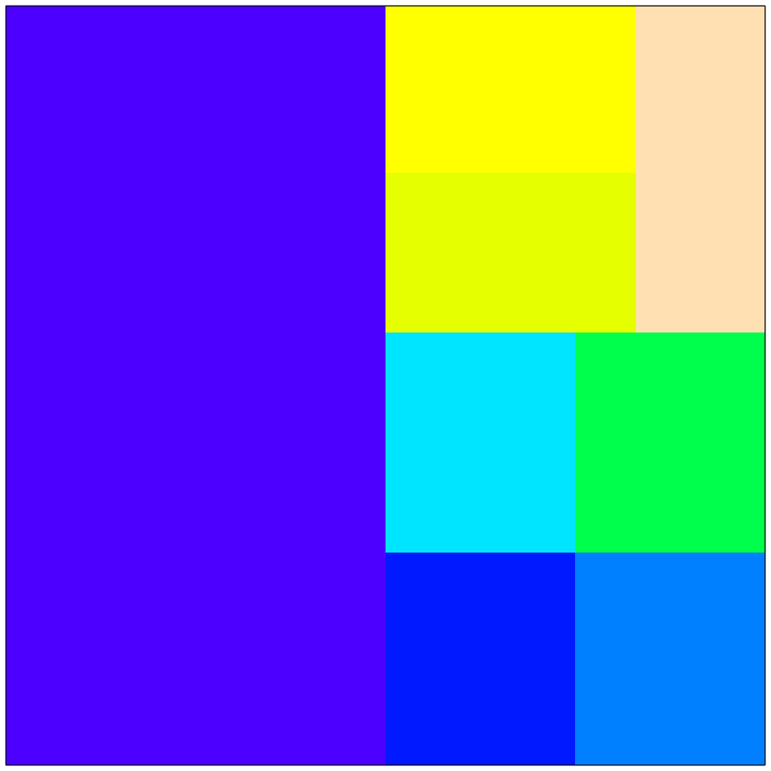

Public land is in dark blue above. If, however, the amount of public land is very small, the land is added to the centre of the landscape. Below illustrates a landscape that also includes seven land owning users, but with `public_land = 0.05`.

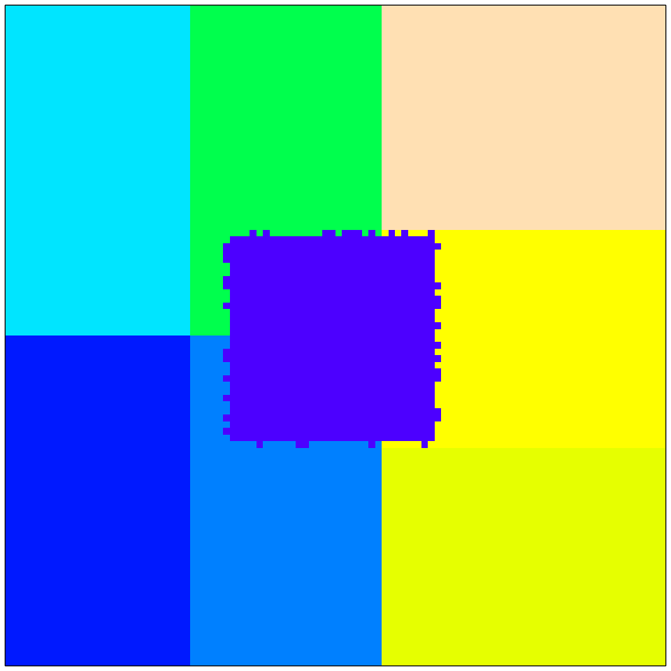

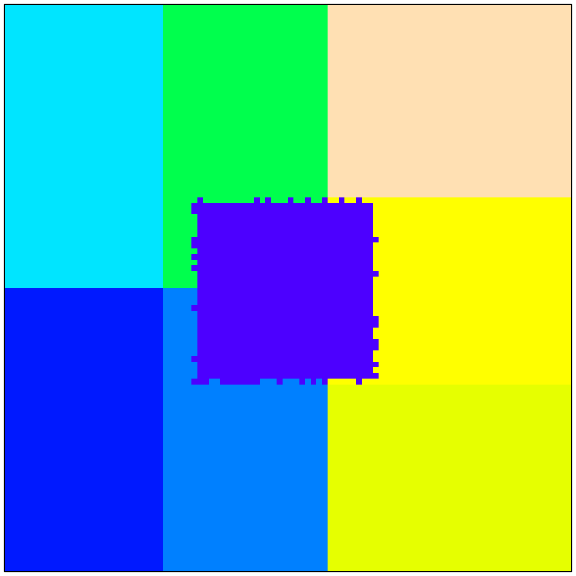

Where `public_land` is small, the default landscape ownership algorithm thereby attempts to be as precise as possible in allocating cell numbers. Of course, as previously mentioned, ownership can also be manually specified when using `gmse_apply`.

# Conclusions

We have focused on the data structures `AGENTS`, `resource_array`, `observation_array`, `manager_array`, `user_array`, and `LAND` because these are the data structures that can be most readily manipulated to customise GMSE simulations. An example of how to do this within a loop using `gmse_apply` can be found in SI4. While other data structures exist within GMSE (e.g., see the output of `gmse_apply` when `get_res = "Full"`), we do not recommend manipulating these structures for custom simulations.

Many data structures contain elements that are unused in GMSE v0.6.0.0, and in all cases this is designed for ease of ongoing development of new GMSE features. Requests for new features can be made on GitHub using the [GMSE Wiki](https://github.com/bradduthie/gmse/wiki) or the [GMSE Issues](https://github.com/bradduthie/gmse/issues) page.

# Reference

Zurell, Damaris, Uta Berger, Juliano S Cabral, Florian Jeltsch, Christine N Meynard, Tamara Münkemüller, Nana Nehrbass, et al. 2010. “The virtual ecologist approach: Simulating data and observers.” *Oikos* 119 (4): 622–35. https://doi.org/10.1111/j.1600-0706.2009.18284.x.